# Mapping aesthetics with formulas

George G. Vega Yon

2026-07-23

One of the most convenient features of `nplot()` is that many aesthetics can be mapped **directly from graph attributes** using a one-sided formula, instead of building the vector of colors, shapes, or sizes by hand. This vignette walks through the different formula interfaces available in **netplot**.

At a glance, `nplot()` understands two flavors of formula:

| Aesthetic | Formula | What it does |
| --- | --- | --- |
| `vertex.color` | `~ attr` | Colors vertices by a vertex attribute (categorical, numeric, logical). |
| `vertex.nsides` | `~ attr` | Maps each unique value of a vertex attribute to a distinct shape. |
| `vertex.size` | `~ attr` | Scales vertex sizes from a numeric vertex attribute. |
| `edge.width` | `~ attr` | Scales edge widths from a numeric edge attribute. |
| `edge.color` | `~ ego(...) + alter(...)` | Blends edge colors from the two endpoints (see the last section). |

```r
library(netplot)
library(igraph)
```

# A working example

We will use the `UKfaculty` network from the **igraphdata** package, a friendship network among faculty at a UK university. It already carries a `Group` vertex attribute (the school/department each person belongs to).

```r
data("UKfaculty", package = "igraphdata")

set.seed(225)
l <- layout_with_fr(UKfaculty)

# A couple of extra attributes to play with. We qualify igraph::degree()
# explicitly because other packages (e.g. sna) also define a degree().
V(UKfaculty)$indeg  <- igraph::degree(UKfaculty, mode = "in")
V(UKfaculty)$is_hub <- V(UKfaculty)$indeg > stats::median(V(UKfaculty)$indeg)
```

# Coloring vertices: `vertex.color = ~ attr`

Passing `vertex.color = ~ Group` colors each vertex according to its `Group` attribute. netplot detects the type of the attribute and picks a sensible scale automatically:

- **character / factor** attributes are mapped to a categorical palette,
- **numeric** attributes to a continuous gradient, and
- **logical** attributes to two contrasting colors.

When you *print* a plot built this way, netplot also draws a matching legend.

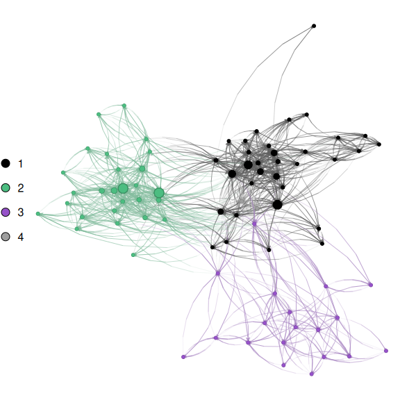

Vertices colored by the categorical `Group` attribute, with an automatic legend.

```r
nplot(UKfaculty, layout = l, vertex.color = ~ Group)
```

The same syntax works for a **numeric** attribute, in which case a continuous color gradient is used. netplot detects that the attribute is continuous and draws a **color bar** (rather than a set of discrete keys) as the legend:

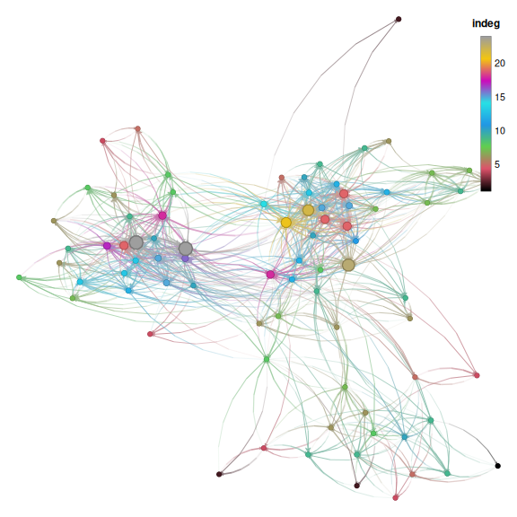

Vertices colored by in-degree (a numeric attribute) using a continuous gradient, with a color-bar legend.

```r
nplot(UKfaculty, layout = l, vertex.color = ~ indeg)
```

And for a **logical** attribute, mapping the two values to two colors:

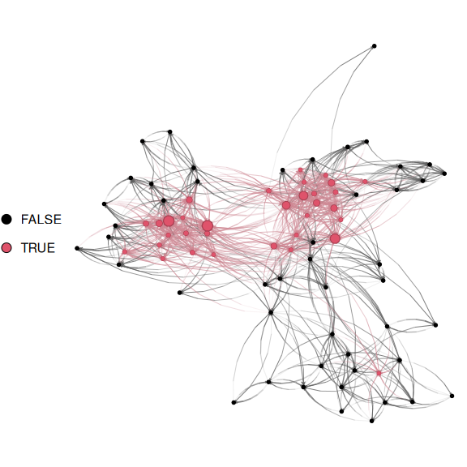

Vertices colored by a logical attribute (hub vs. non-hub).

```r
nplot(UKfaculty, layout = l, vertex.color = ~ is_hub)
```

# Shaping vertices: `vertex.nsides = ~ attr`

`vertex.nsides` controls the number of sides of each vertex polygon (3 = a triangle, 4 = a square, and larger numbers approximate a circle). Passing a formula maps every unique value of the attribute to a **distinct shape**, which is handy for encoding a second categorical variable alongside color:

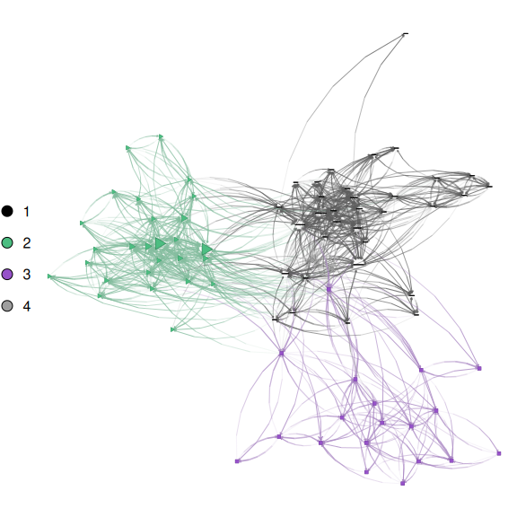

Vertex color *and* shape mapped from the same `Group` attribute.

```r
nplot(
  UKfaculty,
  layout        = l,
  vertex.color  = ~ Group,
  vertex.nsides = ~ Group
)
```

Because each group gets both a color and a shape, the figure stays readable even when printed in grayscale.

# Sizing vertices: `vertex.size = ~ attr`

`vertex.size` accepts a formula naming a **numeric** vertex attribute. Values are rescaled to the range given by `vertex.size.range`, so more central actors show up as larger nodes:

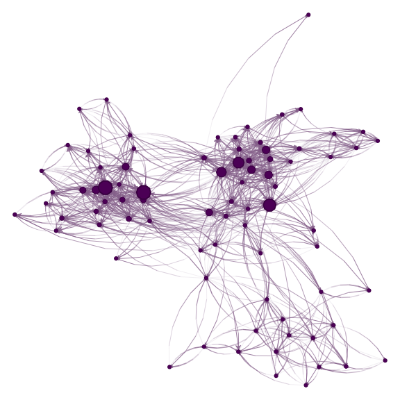

Vertex size mapped from in-degree.

```r
nplot(
  UKfaculty,
  layout            = l,
  vertex.size       = ~ indeg,
  vertex.size.range = c(.01, .04, 4)
)
```

# Putting it together

The formula interfaces compose, so a single `nplot()` call can encode several variables at once — color, shape, and size — with very little code:

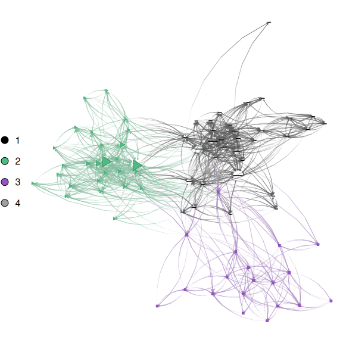

Color, shape, and size all mapped from graph attributes in a single call.

```r
nplot(
  UKfaculty,
  layout            = l,
  vertex.color      = ~ Group,   # color by department
  vertex.nsides     = ~ Group,   # distinct shape per department
  vertex.size       = ~ indeg,   # size by popularity (in-degree)
  vertex.size.range = c(.01, .04, 4)
)
```

# Scaling edges: `edge.width = ~ attr`

Edges have their own numeric attributes too. `edge.width = ~ attr` scales edge widths from a numeric **edge** attribute; the values are normalized and mapped to `edge.width.range`. Here we use the friendship `weight`:

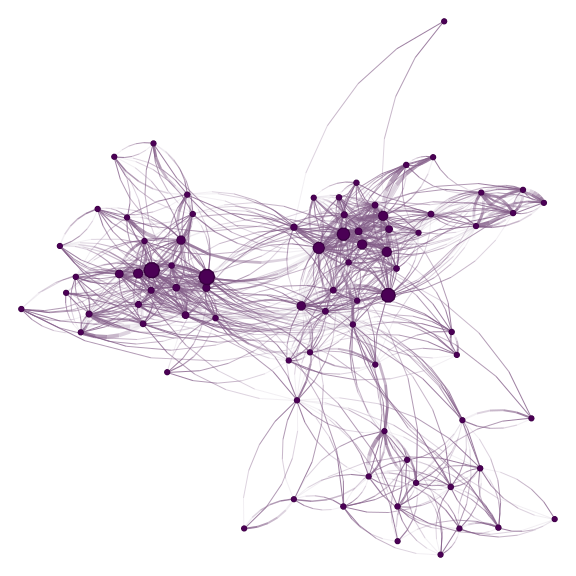

Edge width mapped from the numeric `weight` edge attribute.

```r
nplot(
  UKfaculty,
  layout           = l,
  edge.width       = ~ weight,
  edge.width.range = c(1, 4, 4),
  skip.arrows      = TRUE
)
```

For `vertex.nsides`, `vertex.size`, and `edge.width`, the right-hand side of the formula is *evaluated* with the graph’s attributes in scope, so you are not limited to bare attribute names — expressions work too, e.g. `edge.width = ~ log1p(weight)` or `vertex.size = ~ degree ^ 2`.

# Coloring edges: `edge.color = ~ ego(...) + alter(...)`

Edge *colors* use a richer, dedicated grammar built from two special terms:

- `ego()` — the **source** vertex of the edge, and
- `alter()` — the **target** vertex.

Each term borrows its color from the corresponding endpoint’s `vertex.color` (unless you pass an explicit `col`), and each accepts three tweaks:

- `col` — the base color,
- `alpha` — transparency, from 0 (transparent) to 1 (opaque), and
- `mix` — how much weight that endpoint contributes when the two colors are blended along the edge.

The default, `~ ego(alpha = .1, col = "gray") + alter`, fades each edge from a faint gray at the source to the target’s color. The panels below vary `mix` to shift the blend from *alter only* to *ego only*:

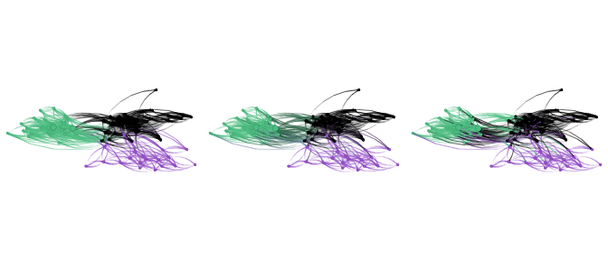

Varying the `mix` between `ego` and `alter` in the edge color formula. Left: alter only. Middle: an even blend. Right: ego only.

```r
gridExtra::grid.arrange(
  nplot(UKfaculty, layout = l, vertex.color = ~ Group,
        edge.color = ~ ego(mix = 0, alpha = .1) + alter(mix = 1)),
  nplot(UKfaculty, layout = l, vertex.color = ~ Group,
        edge.color = ~ ego(mix = .5, alpha = .1) + alter(mix = .5)),
  nplot(UKfaculty, layout = l, vertex.color = ~ Group,
        edge.color = ~ ego(mix = 1, alpha = .1) + alter(mix = 0)),
  ncol = 3
)
```

# Applying formulas after the fact

The attribute-mapping formulas for vertex color also work with `set_vertex_gpar()`, so you can recolor an existing plot without rebuilding it:

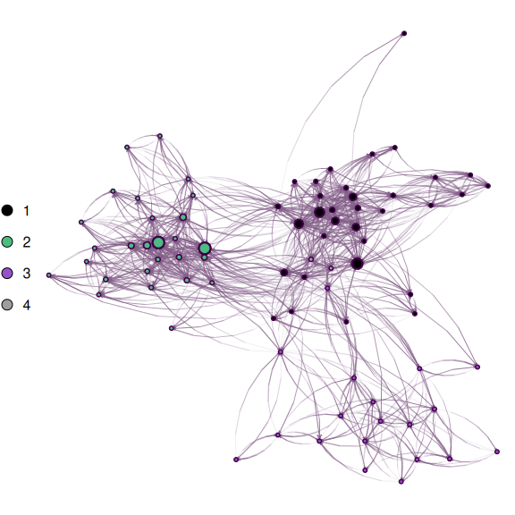

Recoloring an existing plot by attribute using `set_vertex_gpar()`.

```r
np <- nplot(UKfaculty, layout = l)

set_vertex_gpar(np, element = "core", fill = ~ Group)
```

# Summary

- Use `vertex.color = ~ attr` to color vertices by an attribute (with an automatic legend), `vertex.nsides = ~ attr` to give each category a shape, and `vertex.size = ~ attr` / `edge.width = ~ attr` to scale sizes and widths from numeric attributes.
- Use `edge.color = ~ ego(...) + alter(...)` to blend edge colors from their endpoints; see `?\`netplot-formulae`` for the full grammar.
- All of these compose, letting a single `nplot()` call encode several variables at once. ```